# Experiment 4b: Study 2

## Sample

*N* = 1378, *M*<sub>age</sub> = 49.41, *SD*<sub>age</sub> = 14.52, 52.15% female

## Contrast analyses

### Control group (no stimulus)

#### Intention to offset

Summary statistics for intention to offset by stimulus

| Stimulus | Mean | SD |
| --- | --- | --- |
| ISNA \| static DSNA | 4.04 | 2.16 |
| no ISNA \| static DSNA | 3.99 | 2.06 |
| ISNA \| dynamic DSNA | 4.21 | 2.02 |
| no ISNA \| dynamic DSNA | 3.89 | 2.12 |
| ISNA \| no DSNA | 4.22 | 2.00 |
| no ISNA \| no DSNA | 4.00 | 2.16 |
| Personal norm appeal | 3.73 | 2.18 |
| Control group (no stimulus) | 3.56 | 2.05 |

Contrast analysis experimental groups vs. control group for the intention to offset

| Predictor | B | SE | t | p |
| --- | --- | --- | --- | --- |
| (Intercept) | 0.57 | 0.231 | 2.48 | 0.013 |
| ISNA \| static DSNA | 0.53 | 0.148 | 3.61 | <0.001 |
| no ISNA \| static DSNA | 0.54 | 0.144 | 3.77 | <0.001 |
| ISNA \| dynamic DSNA | 0.69 | 0.148 | 4.67 | <0.001 |
| no ISNA \| dynamic DSNA | 0.43 | 0.148 | 2.90 | 0.004 |
| ISNA \| no DSNA | 0.45 | 0.146 | 3.12 | 0.002 |
| no ISNA \| no DSNA | 0.44 | 0.145 | 3.06 | 0.002 |
| Gender | 0.06 | 0.081 | 0.80 | 0.422 |
| Age | 0.00 | 0.003 | -0.25 | 0.800 |
| T1 measurement | 0.78 | 0.020 | 39.10 | <0.001 |

#### Attitude towards VCO

Summary statistics for attitude towards VCO by stimulus

| Stimulus | Mean | SD |
| --- | --- | --- |
| ISNA \| static DSNA | 4.95 | 1.85 |
| no ISNA \| static DSNA | 5.02 | 1.73 |
| ISNA \| dynamic DSNA | 5.16 | 1.78 |
| no ISNA \| dynamic DSNA | 4.79 | 1.87 |
| ISNA \| no DSNA | 5.07 | 1.81 |
| no ISNA \| no DSNA | 4.83 | 1.91 |
| Personal norm appeal | 4.91 | 1.73 |
| Control group (no stimulus) | 4.71 | 1.64 |

Contrast analysis experimental groups vs. control group for the attitude towards VCO

| Predictor | B | SE | t | p |
| --- | --- | --- | --- | --- |
| (Intercept) | 1.67 | 0.244 | 6.85 | <0.001 |
| ISNA \| static DSNA | 0.28 | 0.147 | 1.91 | 0.057 |
| no ISNA \| static DSNA | 0.31 | 0.143 | 2.15 | 0.032 |
| ISNA \| dynamic DSNA | 0.37 | 0.147 | 2.50 | 0.012 |
| no ISNA \| dynamic DSNA | 0.31 | 0.147 | 2.11 | 0.035 |
| ISNA \| no DSNA | 0.28 | 0.145 | 1.92 | 0.056 |
| no ISNA \| no DSNA | 0.14 | 0.144 | 0.95 | 0.343 |
| Gender | -0.01 | 0.080 | -0.19 | 0.851 |
| Age | -0.01 | 0.003 | -2.46 | 0.014 |
| T1 measurement | 0.70 | 0.024 | 29.51 | <0.001 |

#### Perceived effectiveness

Summary statistics for the perceived effectiveness of VCO by stimulus

| Stimulus | Mean | SD |
| --- | --- | --- |
| ISNA \| static DSNA | 4.28 | 1.83 |
| no ISNA \| static DSNA | 4.33 | 1.72 |
| ISNA \| dynamic DSNA | 4.39 | 1.80 |
| no ISNA \| dynamic DSNA | 4.20 | 1.82 |
| ISNA \| no DSNA | 4.35 | 1.66 |
| no ISNA \| no DSNA | 4.14 | 1.85 |
| Personal norm appeal | 4.19 | 1.82 |
| Control group (no stimulus) | 3.78 | 1.70 |

Contrast analysis experimental groups vs. control group for the perceived effectiveness of VCO

| Predictor | B | SE | t | p |
| --- | --- | --- | --- | --- |
| (Intercept) | 0.78 | 0.223 | 3.49 | <0.001 |
| ISNA \| static DSNA | 0.60 | 0.140 | 4.31 | <0.001 |
| no ISNA \| static DSNA | 0.51 | 0.136 | 3.71 | <0.001 |
| ISNA \| dynamic DSNA | 0.67 | 0.140 | 4.78 | <0.001 |
| no ISNA \| dynamic DSNA | 0.66 | 0.139 | 4.75 | <0.001 |
| ISNA \| no DSNA | 0.51 | 0.138 | 3.70 | <0.001 |
| no ISNA \| no DSNA | 0.50 | 0.137 | 3.68 | <0.001 |
| Gender | 0.02 | 0.076 | 0.26 | 0.797 |
| Age | 0.00 | 0.003 | -0.30 | 0.761 |
| T1 measurement | 0.73 | 0.023 | 32.06 | <0.001 |

### Control group (no social norm appeal)

#### Intention to offset

Contrast analysis experimental groups vs. control group for the intention to offset

| Predictor | B | SE | t | p |
| --- | --- | --- | --- | --- |
| (Intercept) | 0.92 | 0.248 | 3.71 | <0.001 |
| ISNA \| static DSNA | 0.09 | 0.152 | 0.59 | 0.552 |
| no ISNA \| static DSNA | 0.10 | 0.149 | 0.64 | 0.520 |
| ISNA \| dynamic DSNA | 0.25 | 0.153 | 1.61 | 0.108 |
| no ISNA \| dynamic DSNA | -0.02 | 0.152 | -0.10 | 0.917 |
| ISNA \| no DSNA | 0.01 | 0.150 | 0.10 | 0.921 |
| Gender | 0.09 | 0.089 | 0.97 | 0.331 |
| Age | 0.00 | 0.003 | 0.45 | 0.653 |
| T1 measurement | 0.77 | 0.022 | 34.86 | <0.001 |

#### Attitude towards VCO

Contrast analysis experimental groups vs. control group for the attitude towards VCO

| Predictor | B | SE | t | p |
| --- | --- | --- | --- | --- |
| (Intercept) | 1.73 | 0.260 | 6.64 | <0.001 |
| ISNA \| static DSNA | 0.14 | 0.151 | 0.95 | 0.342 |
| no ISNA \| static DSNA | 0.17 | 0.147 | 1.15 | 0.252 |
| ISNA \| dynamic DSNA | 0.23 | 0.151 | 1.52 | 0.130 |
| no ISNA \| dynamic DSNA | 0.18 | 0.151 | 1.17 | 0.244 |
| ISNA \| no DSNA | 0.14 | 0.149 | 0.94 | 0.347 |
| Gender | -0.02 | 0.089 | -0.25 | 0.805 |
| Age | -0.01 | 0.003 | -1.91 | 0.056 |
| T1 measurement | 0.71 | 0.026 | 27.05 | <0.001 |

#### Perceived effectiveness

Contrast analysis experimental groups vs. control group for perceived effectiveness of VCO

| Predictor | B | SE | t | p |
| --- | --- | --- | --- | --- |
| (Intercept) | 1.29 | 0.237 | 5.45 | <0.001 |
| ISNA \| static DSNA | 0.10 | 0.143 | 0.68 | 0.496 |
| no ISNA \| static DSNA | 0.00 | 0.140 | 0.02 | 0.987 |
| ISNA \| dynamic DSNA | 0.16 | 0.144 | 1.14 | 0.253 |
| no ISNA \| dynamic DSNA | 0.16 | 0.143 | 1.10 | 0.271 |
| ISNA \| no DSNA | 0.01 | 0.141 | 0.05 | 0.960 |
| Gender | 0.02 | 0.084 | 0.23 | 0.818 |
| Age | 0.00 | 0.003 | -0.17 | 0.863 |
| T1 measurement | 0.72 | 0.025 | 28.93 | <0.001 |

### Control group (personal norm appeal)

#### Intention to offset

Contrast analysis experimental groups vs. control group for the intention to offset

| Predictor | B | SE | t | p |
| --- | --- | --- | --- | --- |
| (Intercept) | 0.84 | 0.227 | 3.68 | <0.001 |
| ISNA \| static DSNA | 0.22 | 0.152 | 1.46 | 0.144 |
| no ISNA \| static DSNA | 0.23 | 0.148 | 1.55 | 0.120 |
| ISNA \| dynamic DSNA | 0.38 | 0.152 | 2.49 | 0.013 |
| no ISNA \| dynamic DSNA | 0.12 | 0.151 | 0.77 | 0.441 |
| ISNA \| no DSNA | 0.14 | 0.150 | 0.94 | 0.346 |
| no ISNA \| no DSNA | 0.13 | 0.149 | 0.89 | 0.374 |
| Gender | 0.04 | 0.082 | 0.52 | 0.601 |
| Age | 0.00 | 0.003 | 0.21 | 0.830 |
| T1 measurement | 0.79 | 0.021 | 38.44 | <0.001 |

#### Attitude towards VCO

Contrast analysis experimental groups vs. control group for the attitude towards VCO

| Predictor | B | SE | t | p |
| --- | --- | --- | --- | --- |
| (Intercept) | 1.79 | 0.234 | 7.67 | <0.001 |
| ISNA \| static DSNA | -0.08 | 0.147 | -0.52 | 0.604 |
| no ISNA \| static DSNA | -0.05 | 0.144 | -0.37 | 0.708 |
| ISNA \| dynamic DSNA | 0.01 | 0.148 | 0.04 | 0.967 |
| no ISNA \| dynamic DSNA | -0.05 | 0.147 | -0.32 | 0.751 |
| ISNA \| no DSNA | -0.08 | 0.146 | -0.54 | 0.588 |
| no ISNA \| no DSNA | -0.22 | 0.145 | -1.55 | 0.122 |
| Gender | 0.07 | 0.080 | 0.82 | 0.412 |
| Age | 0.00 | 0.003 | -1.75 | 0.080 |
| T1 measurement | 0.70 | 0.023 | 30.03 | <0.001 |

#### Perceived effectiveness

Contrast analysis experimental groups vs. control group for perceived effectiveness

| Predictor | B | SE | t | p |
| --- | --- | --- | --- | --- |
| (Intercept) | 1.26 | 0.215 | 5.83 | <0.001 |
| ISNA \| static DSNA | 0.03 | 0.141 | 0.23 | 0.819 |
| no ISNA \| static DSNA | -0.07 | 0.138 | -0.49 | 0.627 |
| ISNA \| dynamic DSNA | 0.10 | 0.141 | 0.69 | 0.491 |
| no ISNA \| dynamic DSNA | 0.09 | 0.140 | 0.67 | 0.502 |
| ISNA \| no DSNA | -0.06 | 0.139 | -0.44 | 0.660 |
| no ISNA \| no DSNA | -0.07 | 0.138 | -0.47 | 0.636 |
| Gender | 0.04 | 0.076 | 0.47 | 0.639 |
| Age | 0.00 | 0.003 | -0.01 | 0.991 |
| T1 measurement | 0.74 | 0.023 | 32.52 | <0.001 |

#### Perceived descriptive norms

Contrast analysis experimental groups vs. control group for perceived descriptive norms

| Predictor | B | SE | t | p |
| --- | --- | --- | --- | --- |
| (Intercept) | 10.44 | 3.409 | 3.06 | 0.002 |
| ISNA \| static DSNA | -6.88 | 2.343 | -2.94 | 0.003 |
| no ISNA \| static DSNA | -8.27 | 2.291 | -3.61 | <0.001 |
| ISNA \| dynamic DSNA | 14.26 | 2.352 | 6.06 | <0.001 |
| no ISNA \| dynamic DSNA | 1.09 | 2.339 | 0.47 | 0.641 |
| ISNA \| no DSNA | 23.40 | 2.313 | 10.12 | <0.001 |
| no ISNA \| no DSNA | -1.90 | 2.303 | -0.83 | 0.409 |
| Gender | 3.20 | 1.270 | 2.52 | 0.012 |
| Age | 0.04 | 0.043 | 0.97 | 0.332 |
| T1 measurement | 0.31 | 0.031 | 10.16 | <0.001 |

#### Perceived trend

Contrast analysis experimental groups vs. control group for perceived trend

| Predictor | B | SE | t | p |
| --- | --- | --- | --- | --- |
| (Intercept) | 3.28 | 0.216 | 15.16 | <0.001 |
| ISNA \| static DSNA | -0.02 | 0.110 | -0.22 | 0.825 |
| no ISNA \| static DSNA | 0.07 | 0.108 | 0.63 | 0.530 |
| ISNA \| dynamic DSNA | 0.75 | 0.111 | 6.76 | <0.001 |
| no ISNA \| dynamic DSNA | 0.51 | 0.110 | 4.65 | <0.001 |
| ISNA \| no DSNA | 0.09 | 0.109 | 0.82 | 0.415 |
| no ISNA \| no DSNA | 0.02 | 0.108 | 0.20 | 0.843 |
| Gender | -0.10 | 0.059 | -1.72 | 0.086 |
| Age | 0.00 | 0.002 | -2.08 | 0.038 |
| T1 measurement | 0.39 | 0.032 | 12.34 | <0.001 |

#### Perceived injunctive norms

Contrast analysis experimental groups vs. control group for perceived injunctive norms

| Predictor | B | SE | t | p |
| --- | --- | --- | --- | --- |
| (Intercept) | 31.45 | 3.752 | 8.38 | <0.001 |
| ISNA \| static DSNA | 23.89 | 2.446 | 9.77 | <0.001 |
| no ISNA \| static DSNA | -5.82 | 2.391 | -2.44 | 0.015 |
| ISNA \| dynamic DSNA | 21.07 | 2.455 | 8.58 | <0.001 |
| no ISNA \| dynamic DSNA | 3.97 | 2.443 | 1.62 | 0.105 |
| ISNA \| no DSNA | 25.05 | 2.414 | 10.38 | <0.001 |
| no ISNA \| no DSNA | 3.07 | 2.403 | 1.28 | 0.202 |
| Gender | 0.92 | 1.319 | 0.70 | 0.485 |
| Age | -0.09 | 0.045 | -1.98 | 0.048 |
| T1 measurement | 0.34 | 0.028 | 12.22 | <0.001 |

# Perceived social norms (Hypothesis H1a-H4a)

## Perceived descriptive norms (Hypothesis 1a)

H1a: A message including a static minority DSNA has a negative effect on the perceived prevalence of the behaviour.

#### Without covariates

|  | η² | Partial η² | SS | df | MS | F | p |
| --- | --- | --- | --- | --- | --- | --- | --- |
| DSNA | 0.102 | 0.114 | 67573 | 2 | 33786.6 | 64.95 | 0 |
| ISNA | 0.066 | 0.077 | 43916 | 1 | 43916.0 | 84.42 | 0 |
| DSNA:ISNA | 0.039 | 0.047 | 26032 | 2 | 13016.0 | 25.02 | 0 |
| Residuals | 0.794 | NA | 526979 | 1013 | 520.2 | NA | NA |

*R*2 = 0.21, *F*(5, 1013) = 52.71, *p* = 0.

#### Including covariates

|  | η² | Partial η² | SS | df | MS | F | p |
| --- | --- | --- | --- | --- | --- | --- | --- |
| DSNA | 0.099 | 0.120 | 65757.4 | 2 | 32878.7 | 68.846 | 0.000 |
| ISNA | 0.067 | 0.085 | 44618.6 | 1 | 44618.6 | 93.429 | 0.000 |
| gender.y | 0.003 | 0.004 | 2068.4 | 1 | 2068.4 | 4.331 | 0.038 |
| age.y | 0.001 | 0.001 | 405.3 | 1 | 405.3 | 0.849 | 0.357 |
| WDN.T1 | 0.063 | 0.080 | 41629.7 | 1 | 41629.7 | 87.170 | 0.000 |
| DSNA:ISNA | 0.037 | 0.049 | 24591.9 | 2 | 12296.0 | 25.747 | 0.000 |
| Residuals | 0.724 | NA | 479954.3 | 1005 | 477.6 | NA | NA |

*R*2 = 0.28, *F*(8, 1005) = 47.8, *p* = 0.

| Contrast | vs | Estimate | SE | t | p |
| --- | --- | --- | --- | --- | --- |
| static - dynamic | 0 | -15.250 | 1.694 | -9.000 | <0.001 |
| absent - dynamic | 0 | 3.084 | 1.689 | 1.825 | 0.162 |
| absent - static | 0 | 18.334 | 1.667 | 10.997 | <0.001 |

Tukey post hoc test DSNA

| Contrast | vs | Estimate | SE | t | p |
| --- | --- | --- | --- | --- | --- |
| static.ISNA present - dynamic.ISNA present | 0 | -21.418 | 2.519 | -8.503 | <0.001 |
| absent.ISNA present - dynamic.ISNA present | 0 | 9.621 | 2.497 | 3.853 | 0.002 |
| dynamic.ISNA absent - dynamic.ISNA present | 0 | -13.664 | 2.523 | -5.416 | <0.001 |
| static.ISNA absent - dynamic.ISNA present | 0 | -22.028 | 2.473 | -8.906 | <0.001 |
| absent.ISNA absent - dynamic.ISNA present | 0 | -15.519 | 2.487 | -6.241 | <0.001 |
| absent.ISNA present - static.ISNA present | 0 | 31.038 | 2.482 | 12.507 | <0.001 |
| dynamic.ISNA absent - static.ISNA present | 0 | 7.754 | 2.507 | 3.093 | 0.025 |
| static.ISNA absent - static.ISNA present | 0 | -0.611 | 2.458 | -0.249 | >0.999 |
| absent.ISNA absent - static.ISNA present | 0 | 5.899 | 2.471 | 2.387 | 0.161 |
| dynamic.ISNA absent - absent.ISNA present | 0 | -23.284 | 2.485 | -9.368 | <0.001 |
| static.ISNA absent - absent.ISNA present | 0 | -31.649 | 2.435 | -12.996 | <0.001 |
| absent.ISNA absent - absent.ISNA present | 0 | -25.139 | 2.449 | -10.265 | <0.001 |
| static.ISNA absent - dynamic.ISNA absent | 0 | -8.365 | 2.462 | -3.398 | 0.009 |
| absent.ISNA absent - dynamic.ISNA absent | 0 | -1.855 | 2.475 | -0.750 | 0.976 |
| absent.ISNA absent - static.ISNA absent | 0 | 6.510 | 2.425 | 2.685 | 0.079 |

**Adjusted means**

DSNA:

- Dynamic: 32.28, CI [29.9, 34.66]
- Static: 17.16, CI [14.84, 19.48]
- Absent: 35.23, CI [32.93, 37.54]

ISNA:

- Present: 35, CI [33.08, 36.93]
- Absent: 21.66, CI [19.78, 23.55]

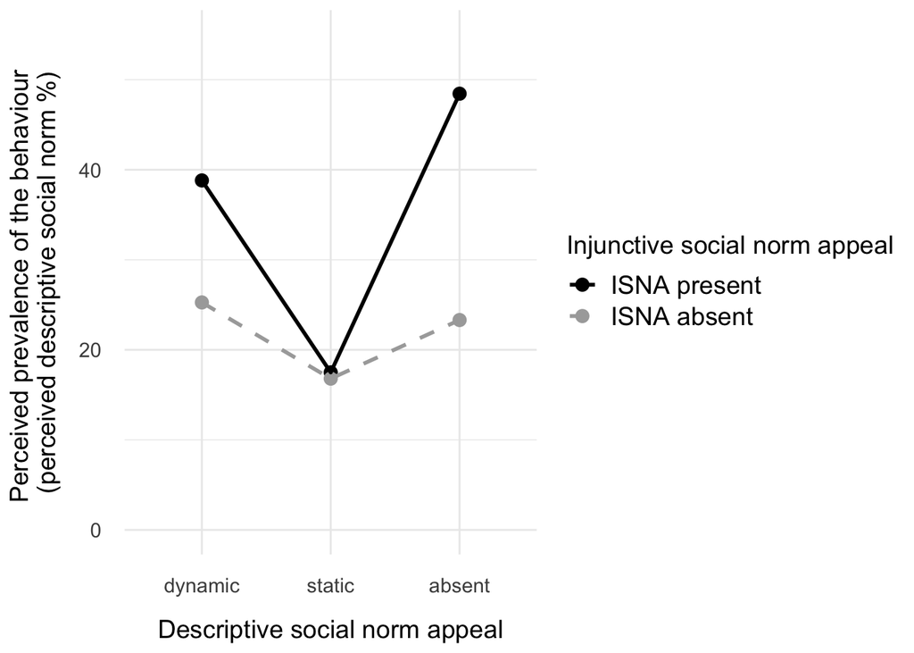

## Perceived trend (Hypothesis 2a and 3a)

H2a: A message including a dynamic DSNA leads to a stronger perception of a trend than a message including a static minority DSNA. H3a: A message including a dynamic DSNA leads to a stronger perception of a trend than a message without a DSNA.

#### Without covariates

|  | η² | Partial η² | SS | df | MS | F | p |
| --- | --- | --- | --- | --- | --- | --- | --- |
| DSNA | 0.063 | 0.063 | 76.257 | 2 | 38.128 | 34.140 | 0.000 |
| ISNA | 0.003 | 0.003 | 3.705 | 1 | 3.705 | 3.317 | 0.069 |
| DSNA:ISNA | 0.005 | 0.006 | 6.581 | 2 | 3.290 | 2.946 | 0.053 |
| Residuals | 0.929 | NA | 1131.326 | 1013 | 1.117 | NA | NA |

*R*2 = 0.07, *F*(5, 1013) = 15.38, *p* = 0.

#### Including covariates

|  | η² | Partial η² | SS | df | MS | F | p |
| --- | --- | --- | --- | --- | --- | --- | --- |
| DSNA | 0.069 | 0.075 | 83.306 | 2 | 41.653 | 40.566 | 0.000 |
| ISNA | 0.002 | 0.002 | 2.020 | 1 | 2.020 | 1.967 | 0.161 |
| gender.y | 0.005 | 0.006 | 5.914 | 1 | 5.914 | 5.759 | 0.017 |
| age.y | 0.008 | 0.009 | 9.260 | 1 | 9.260 | 9.019 | 0.003 |
| trend.T1 | 0.066 | 0.072 | 80.228 | 1 | 80.228 | 78.133 | 0.000 |
| DSNA:ISNA | 0.004 | 0.005 | 5.321 | 2 | 2.661 | 2.591 | 0.075 |
| Residuals | 0.855 | NA | 1031.943 | 1005 | 1.027 | NA | NA |

*R*2 = 0.14, *F*(8, 1005) = 21.25, *p* = 0.

Tukey post hoc test

| Contrast | vs | Estimate | SE | t | p |
| --- | --- | --- | --- | --- | --- |
| static - dynamic | 0 | -0.624 | 0.079 | -7.935 | <0.001 |
| absent - dynamic | 0 | -0.606 | 0.078 | -7.739 | <0.001 |
| absent - static | 0 | 0.018 | 0.077 | 0.232 | 0.971 |

**Adjusted means**

DSNA:

- Dynamic: 5.33, CI [5.22, 5.45]
- Static: 4.71, CI [4.61, 4.82]
- Absent: 4.73, CI [4.62, 4.84]

ISNA:

- Present: 4.96, CI [4.87, 5.05]
- Absent: 4.88, CI [4.79, 4.96]

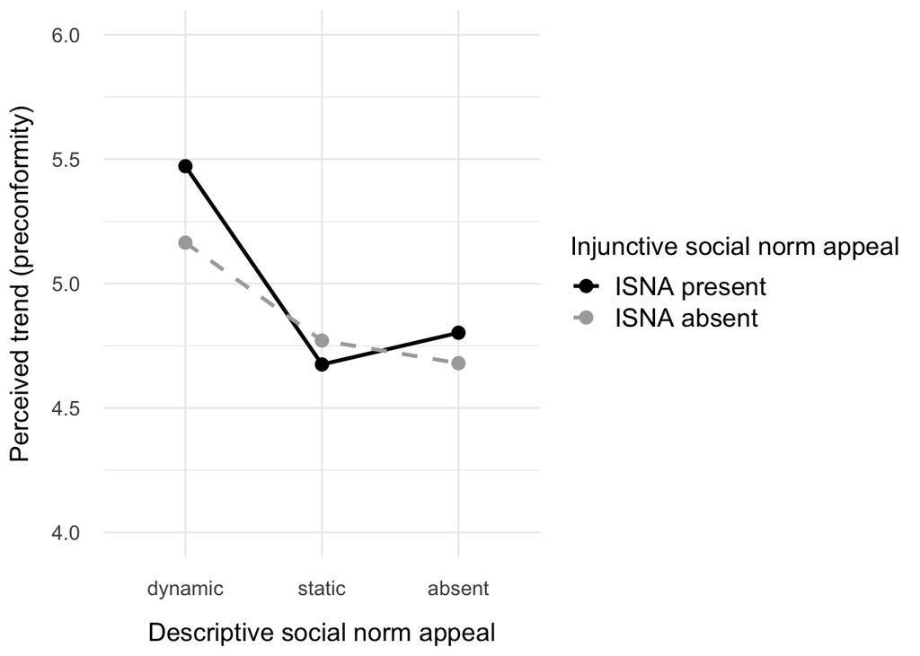

## Perceived injunctive norms (Hypothesis 4a)

#### Without covariates

|  | η² | Partial η² | SS | df | MS | F | p |
| --- | --- | --- | --- | --- | --- | --- | --- |
| DSNA | 0.008 | 0.010 | 5573 | 2 | 2786.6 | 4.887 | 0.008 |
| ISNA | 0.197 | 0.201 | 145431 | 1 | 145430.8 | 255.054 | 0.000 |
| DSNA:ISNA | 0.011 | 0.014 | 7944 | 2 | 3971.8 | 6.966 | 0.001 |
| Residuals | 0.782 | NA | 577609 | 1013 | 570.2 | NA | NA |

*R*2 = 0.22, *F*(5, 1013) = 56.61, *p* = 0.

#### Including covariates

|  | η² | Partial η² | SS | df | MS | F | p |
| --- | --- | --- | --- | --- | --- | --- | --- |
| DSNA | 0.006 | 0.009 | 4591.47 | 2 | 2295.74 | 4.519 | 0.011 |
| ISNA | 0.181 | 0.207 | 132961.59 | 1 | 132961.59 | 261.714 | 0.000 |
| gender.y | 0.000 | 0.000 | 90.71 | 1 | 90.71 | 0.179 | 0.673 |
| age.y | 0.002 | 0.003 | 1509.81 | 1 | 1509.81 | 2.972 | 0.085 |
| WIN.T1 | 0.080 | 0.104 | 59199.49 | 1 | 59199.49 | 116.525 | 0.000 |
| DSNA:ISNA | 0.009 | 0.013 | 6765.21 | 2 | 3382.61 | 6.658 | 0.001 |
| Residuals | 0.694 | NA | 510581.39 | 1005 | 508.04 | NA | NA |

*R*2 = 0.31, *F*(8, 1005) = 55.33, *p* = 0.

Tukey post hoc test DSNA

| Contrast | vs | Estimate | SE | t | p |
| --- | --- | --- | --- | --- | --- |
| static.ISNA present - dynamic.ISNA present | 0 | 3.396 | 2.637 | 1.288 | 0.792 |
| absent.ISNA present - dynamic.ISNA present | 0 | 4.751 | 2.614 | 1.817 | 0.455 |
| dynamic.ISNA absent - dynamic.ISNA present | 0 | -17.720 | 2.641 | -6.709 | <0.001 |
| static.ISNA absent - dynamic.ISNA present | 0 | -27.894 | 2.589 | -10.772 | <0.001 |
| absent.ISNA absent - dynamic.ISNA present | 0 | -17.964 | 2.603 | -6.900 | <0.001 |
| absent.ISNA present - static.ISNA present | 0 | 1.355 | 2.598 | 0.522 | 0.995 |
| dynamic.ISNA absent - static.ISNA present | 0 | -21.115 | 2.625 | -8.044 | <0.001 |
| static.ISNA absent - static.ISNA present | 0 | -31.289 | 2.573 | -12.161 | <0.001 |
| absent.ISNA absent - static.ISNA present | 0 | -21.359 | 2.587 | -8.256 | <0.001 |
| dynamic.ISNA absent - absent.ISNA present | 0 | -22.471 | 2.602 | -8.636 | <0.001 |
| static.ISNA absent - absent.ISNA present | 0 | -32.644 | 2.550 | -12.804 | <0.001 |
| absent.ISNA absent - absent.ISNA present | 0 | -22.714 | 2.564 | -8.859 | <0.001 |
| static.ISNA absent - dynamic.ISNA absent | 0 | -10.174 | 2.577 | -3.948 | 0.001 |
| absent.ISNA absent - dynamic.ISNA absent | 0 | -0.244 | 2.591 | -0.094 | >0.999 |
| absent.ISNA absent - static.ISNA absent | 0 | 9.930 | 2.538 | 3.912 | 0.001 |

Tukey post hoc test

| Contrast | vs | Estimate | SE | t | p |
| --- | --- | --- | --- | --- | --- |
| static - dynamic | 0 | -3.492 | 1.747 | -1.999 | 0.113 |
| absent - dynamic | 0 | 1.566 | 1.741 | 0.899 | 0.641 |
| absent - static | 0 | 5.058 | 1.720 | 2.941 | 0.009 |

**Adjusted means**

DSNA:

- Dynamic: 53.72, CI [51.27, 56.18]
- Static: 50.09, CI [47.7, 52.49]
- Absent: 55.24, CI [52.86, 57.61]

ISNA:

- Present: 64.79, CI [62.8, 66.78]
- Absent: 41.74, CI [39.8, 43.69]

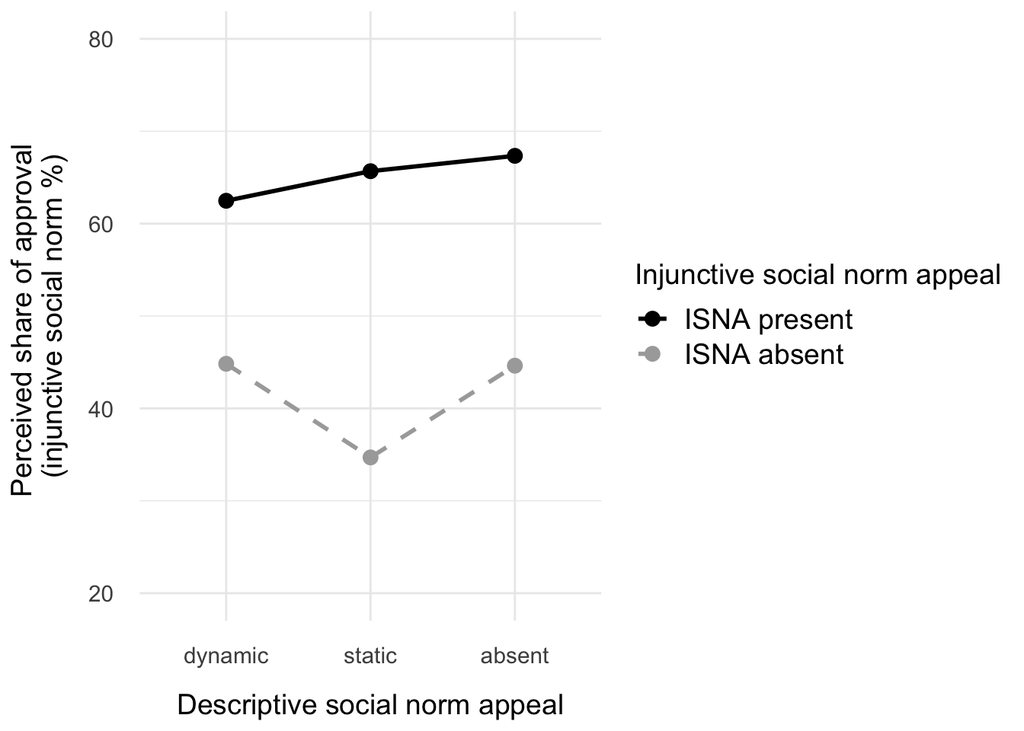

# Persuasive effects (Hypothesis H1b-H4b)

H2b: A message including a dynamic DSNA is more persuasive than a message including a static minority DSNA.

H3b: A message including a dynamic DSNA is more persuasive than a message without a DSNA.

H4b: A message including a majority ISNA is more persuasive than a message without a majority ISNA.

#### MANCOVA without covariates

|  | df | Pillai | F | num df | den df | p |
| --- | --- | --- | --- | --- | --- | --- |
| DSNA | 2 | 0.003 | 0.434 | 6 | 2024 | 0.857 |
| ISNA | 1 | 0.003 | 0.996 | 3 | 1011 | 0.394 |
| DSNA:ISNA | 2 | 0.004 | 0.592 | 6 | 2024 | 0.737 |
| Residuals | 1013 | NA | NA | NA | NA | NA |

#### MANCOVA including covariates

|  | df | Pillai | F | num df | den df | p |
| --- | --- | --- | --- | --- | --- | --- |
| DSNA | 2 | 0.003 | 0.537 | 6 | 2004 | 0.780 |
| ISNA | 1 | 0.006 | 2.086 | 3 | 1001 | 0.100 |
| Gender | 1 | 0.030 | 10.194 | 3 | 1001 | 0.000 |
| Age | 1 | 0.015 | 4.967 | 3 | 1001 | 0.002 |
| Intention.T1 | 1 | 0.581 | 463.550 | 3 | 1001 | 0.000 |
| Attitude.T1 | 1 | 0.193 | 79.752 | 3 | 1001 | 0.000 |
| PCE.T1 | 1 | 0.153 | 60.276 | 3 | 1001 | 0.000 |
| DSNA:ISNA | 2 | 0.002 | 0.397 | 6 | 2004 | 0.881 |
| Residuals | 1003 | NA | NA | NA | NA | NA |

#### Intention to offset

**Without covariates**

|  | η² | Partial η² | SS | df | MS | F | p |
| --- | --- | --- | --- | --- | --- | --- | --- |
| DSNA | 0.000 | 0.000 | 1.623 | 2 | 0.812 | 0.186 | 0.830 |
| ISNA | 0.002 | 0.002 | 10.041 | 1 | 10.041 | 2.303 | 0.129 |
| DSNA:ISNA | 0.001 | 0.001 | 3.036 | 2 | 1.518 | 0.348 | 0.706 |
| Residuals | 0.997 | NA | 4417.613 | 1013 | 4.361 | NA | NA |

*R*2 = 0, *F*(5, 1013) = 0.67, *p* = 0.65.

**Including covariates:**

|  | η² | Partial η² | SS | df | MS | F | p |
| --- | --- | --- | --- | --- | --- | --- | --- |
| DSNA | 0.000 | 0.001 | 2.189 | 2 | 1.095 | 0.560 | 0.572 |
| ISNA | 0.000 | 0.001 | 2.069 | 1 | 2.069 | 1.058 | 0.304 |
| gender.y | 0.000 | 0.001 | 1.850 | 1 | 1.850 | 0.946 | 0.331 |
| age.y | 0.000 | 0.000 | 0.396 | 1 | 0.396 | 0.203 | 0.653 |
| Intention.T1 | 0.539 | 0.547 | 2376.784 | 1 | 2376.784 | 1215.297 | 0.000 |
| DSNA:ISNA | 0.001 | 0.002 | 3.642 | 2 | 1.821 | 0.931 | 0.394 |
| Residuals | 0.445 | NA | 1965.501 | 1005 | 1.956 | NA | NA |

*R*2 = 0.55, *F*(8, 1005) = 156.46, *p* = 0.

*R*2 = 0.56, *F*(13, 1000) = 97.18, *p* = 0.

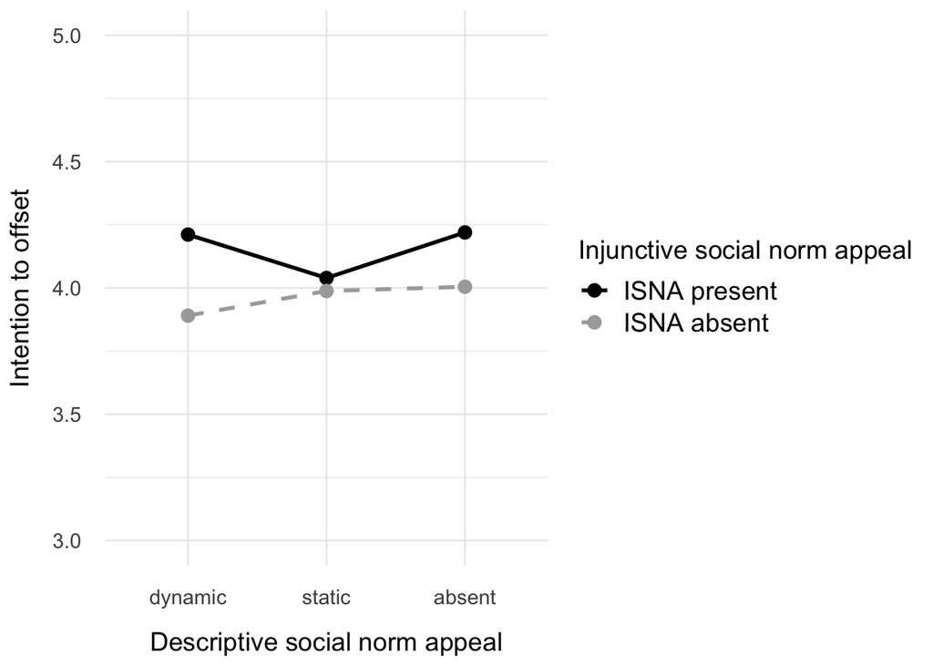

#### Attitude towards VCO

**Without covariates:**

|  | η² | Partial η² | SS | df | MS | F | p |
| --- | --- | --- | --- | --- | --- | --- | --- |
| DSNA | 0.000 | 0.000 | 0.267 | 2 | 0.134 | 0.040 | 0.961 |
| ISNA | 0.002 | 0.002 | 8.283 | 1 | 8.283 | 2.486 | 0.115 |
| DSNA:ISNA | 0.003 | 0.003 | 8.700 | 2 | 4.350 | 1.306 | 0.271 |
| Residuals | 0.995 | NA | 3374.787 | 1013 | 3.331 | NA | NA |

*R*2 = 0.01, *F*(5, 1013) = 1.02, *p* = 0.4.

**Including covariates:**

|  | η² | Partial η² | SS | df | MS | F | p |
| --- | --- | --- | --- | --- | --- | --- | --- |
| DSNA | 0.001 | 0.002 | 3.046 | 2 | 1.523 | 0.796 | 0.451 |
| ISNA | 0.000 | 0.000 | 0.789 | 1 | 0.789 | 0.413 | 0.521 |
| gender.y | 0.000 | 0.000 | 0.116 | 1 | 0.116 | 0.061 | 0.805 |
| age.y | 0.002 | 0.004 | 6.991 | 1 | 6.991 | 3.656 | 0.056 |
| Attitude.T1 | 0.415 | 0.421 | 1399.419 | 1 | 1399.419 | 731.809 | 0.000 |
| DSNA:ISNA | 0.000 | 0.001 | 1.176 | 2 | 0.588 | 0.308 | 0.735 |
| Residuals | 0.569 | NA | 1921.836 | 1005 | 1.912 | NA | NA |

*R*2 = 0.43, *F*(8, 1005) = 94.99, *p* = 0.

*R*2 = 0.43, *F*(13, 1000) = 58.57, *p* = 0.

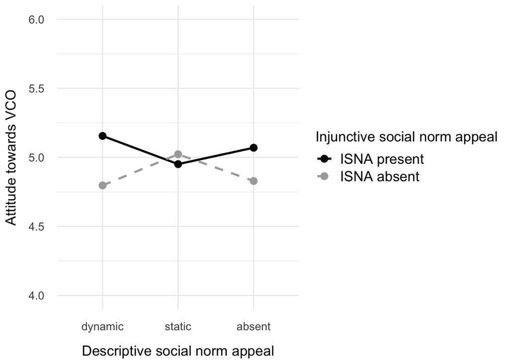

#### Perceived effectiveness of VCO

**Without covariates:**

|  | η² | Partial η² | SS | df | MS | F | p |
| --- | --- | --- | --- | --- | --- | --- | --- |
| DSNA | 0.000 | 0.000 | 0.696 | 2 | 0.348 | 0.109 | 0.896 |
| ISNA | 0.001 | 0.001 | 3.425 | 1 | 3.425 | 1.078 | 0.299 |
| DSNA:ISNA | 0.001 | 0.001 | 3.374 | 2 | 1.687 | 0.531 | 0.588 |
| Residuals | 0.998 | NA | 3219.807 | 1013 | 3.178 | NA | NA |

*R*2 = 0, *F*(5, 1013) = 0.47, *p* = 0.8.

**Including covariates:**

|  | η² | Partial η² | SS | df | MS | F | p |
| --- | --- | --- | --- | --- | --- | --- | --- |
| DSNA | 0.001 | 0.002 | 4.344 | 2 | 2.172 | 1.259 | 0.285 |
| ISNA | 0.000 | 0.000 | 0.335 | 1 | 0.335 | 0.194 | 0.660 |
| gender.y | 0.000 | 0.000 | 0.091 | 1 | 0.091 | 0.053 | 0.818 |
| age.y | 0.000 | 0.000 | 0.051 | 1 | 0.051 | 0.030 | 0.863 |
| PCE.T1 | 0.450 | 0.454 | 1444.635 | 1 | 1444.635 | 837.018 | 0.000 |
| DSNA:ISNA | 0.000 | 0.000 | 0.438 | 2 | 0.219 | 0.127 | 0.881 |
| Residuals | 0.541 | NA | 1734.560 | 1005 | 1.726 | NA | NA |

*R*2 = 0.46, *F*(8, 1005) = 106.63, *p* = 0.

*R*2 = 0.46, *F*(13, 1000) = 65.75, *p* = 0.

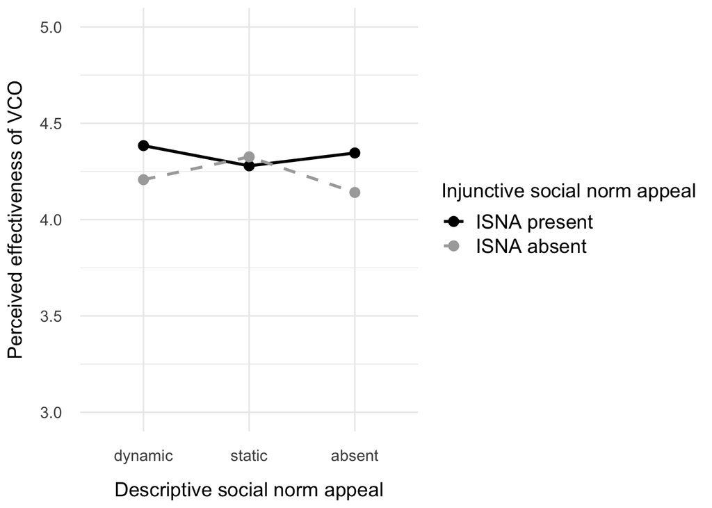

# Environmental dispositions (Hypothesis 5)

### Personal norms

#### Median split including covariates

|  | df | Pillai | F | num df | den df | p |
| --- | --- | --- | --- | --- | --- | --- |
| DSNA | 2 | 0.003 | 0.540 | 6 | 1992 | 0.778 |
| ISNA | 1 | 0.006 | 2.111 | 3 | 995 | 0.097 |
| PN_factor | 1 | 0.460 | 282.022 | 3 | 995 | 0.000 |
| Gender | 1 | 0.008 | 2.715 | 3 | 995 | 0.044 |
| Age | 1 | 0.017 | 5.880 | 3 | 995 | 0.001 |
| intention.x | 1 | 0.377 | 200.701 | 3 | 995 | 0.000 |
| attitude.x | 1 | 0.192 | 78.681 | 3 | 995 | 0.000 |
| PCE.x | 1 | 0.155 | 60.729 | 3 | 995 | 0.000 |
| DSNA:ISNA | 2 | 0.002 | 0.407 | 6 | 1992 | 0.875 |
| DSNA:PN_factor | 2 | 0.009 | 1.582 | 6 | 1992 | 0.148 |
| ISNA:PN_factor | 1 | 0.005 | 1.574 | 3 | 995 | 0.194 |
| DSNA:ISNA:PN_factor | 2 | 0.010 | 1.633 | 6 | 1992 | 0.134 |
| Residuals | 997 | NA | NA | NA | NA | NA |

#### Metric including covariates

|  | df | Pillai | F | num df | den df | p |
| --- | --- | --- | --- | --- | --- | --- |
| DSNA | 2 | 0.003 | 0.541 | 6 | 1992 | 0.777 |
| ISNA | 1 | 0.007 | 2.191 | 3 | 995 | 0.088 |
| PN | 1 | 0.581 | 459.933 | 3 | 995 | 0.000 |
| gender.y | 1 | 0.005 | 1.700 | 3 | 995 | 0.165 |
| age.y | 1 | 0.014 | 4.857 | 3 | 995 | 0.002 |
| Intention.T1 | 1 | 0.185 | 75.196 | 3 | 995 | 0.000 |
| Attitude.T1 | 1 | 0.172 | 68.918 | 3 | 995 | 0.000 |
| PCE.T1 | 1 | 0.147 | 57.308 | 3 | 995 | 0.000 |
| DSNA:ISNA | 2 | 0.002 | 0.322 | 6 | 1992 | 0.926 |
| DSNA:PN | 2 | 0.011 | 1.799 | 6 | 1992 | 0.095 |
| ISNA:PN | 1 | 0.003 | 0.958 | 3 | 995 | 0.412 |
| DSNA:ISNA:PN | 2 | 0.007 | 1.216 | 6 | 1992 | 0.295 |
| Residuals | 997 | NA | NA | NA | NA | NA |

# Additional analyses

### Environmental awareness

#### Median split including covariates

|  | df | Pillai | F | num df | den df | p |
| --- | --- | --- | --- | --- | --- | --- |
| DSNA | 2 | 0.003 | 0.538 | 6 | 1992 | 0.780 |
| ISNA | 1 | 0.006 | 2.107 | 3 | 995 | 0.098 |
| EA_factor | 1 | 0.353 | 181.279 | 3 | 995 | 0.000 |
| Gender | 1 | 0.012 | 4.192 | 3 | 995 | 0.006 |
| Age | 1 | 0.019 | 6.330 | 3 | 995 | 0.000 |
| Intention.T1 | 1 | 0.478 | 303.462 | 3 | 995 | 0.000 |
| Attitude.T1 | 1 | 0.183 | 74.472 | 3 | 995 | 0.000 |
| PCE.T1 | 1 | 0.155 | 61.053 | 3 | 995 | 0.000 |
| DSNA:ISNA | 2 | 0.003 | 0.422 | 6 | 1992 | 0.865 |
| DSNA:EA_factor | 2 | 0.002 | 0.389 | 6 | 1992 | 0.886 |
| ISNA:EA_factor | 1 | 0.006 | 2.061 | 3 | 995 | 0.104 |
| DSNA:ISNA:EA_factor | 2 | 0.007 | 1.211 | 6 | 1992 | 0.297 |
| Residuals | 997 | NA | NA | NA | NA | NA |

#### Metric including covariates

|  | df | Pillai | F | num df | den df | p |
| --- | --- | --- | --- | --- | --- | --- |
| DSNA | 2 | 0.003 | 0.535 | 6 | 1992 | 0.782 |
| ISNA | 1 | 0.006 | 2.161 | 3 | 995 | 0.091 |
| EA | 1 | 0.485 | 312.870 | 3 | 995 | 0.000 |
| Gender | 1 | 0.004 | 1.300 | 3 | 995 | 0.273 |
| Age | 1 | 0.017 | 5.568 | 3 | 995 | 0.001 |
| Intention.T1 | 1 | 0.394 | 215.415 | 3 | 995 | 0.000 |
| Attitude.T1 | 1 | 0.158 | 62.097 | 3 | 995 | 0.000 |
| PCE.T1 | 1 | 0.152 | 59.306 | 3 | 995 | 0.000 |
| DSNA:ISNA | 2 | 0.003 | 0.421 | 6 | 1992 | 0.865 |
| DSNA:EA | 2 | 0.003 | 0.560 | 6 | 1992 | 0.762 |
| ISNA:EA | 1 | 0.001 | 0.183 | 3 | 995 | 0.908 |
| DSNA:ISNA:EA | 2 | 0.007 | 1.198 | 6 | 1992 | 0.304 |
| Residuals | 997 | NA | NA | NA | NA | NA |

### Gender

#### MANOVA without covariates (intention, attitude, perceived effectiveness)

|  | df | Pillai | F | num df | den df | p |
| --- | --- | --- | --- | --- | --- | --- |
| DSNA | 2 | 0.002 | 0.371 | 6 | 1948 | 0.898 |
| ISNA | 1 | 0.003 | 0.858 | 3 | 973 | 0.462 |
| Gender | 1 | 0.012 | 3.966 | 3 | 973 | 0.008 |
| DSNA:ISNA | 2 | 0.003 | 0.556 | 6 | 1948 | 0.766 |
| DSNA:Gender | 2 | 0.004 | 0.611 | 6 | 1948 | 0.722 |
| ISNA:Gender | 1 | 0.008 | 2.517 | 3 | 973 | 0.057 |
| DSNA:ISNA:Gender | 2 | 0.015 | 2.528 | 6 | 1948 | 0.019 |
| Residuals | 975 | NA | NA | NA | NA | NA |

#### MANOVA including covariates

|  | df | Pillai | F | num df | den df | p |
| --- | --- | --- | --- | --- | --- | --- |
| DSNA | 2 | 0.003 | 0.437 | 6 | 1936 | 0.854 |
| ISNA | 1 | 0.006 | 1.880 | 3 | 967 | 0.131 |
| Gender | 1 | 0.031 | 10.222 | 3 | 967 | 0.000 |
| PN | 1 | 0.582 | 449.032 | 3 | 967 | 0.000 |
| EA | 1 | 0.039 | 12.943 | 3 | 967 | 0.000 |
| age.y | 1 | 0.014 | 4.427 | 3 | 967 | 0.004 |
| Intention.T1 | 1 | 0.183 | 72.195 | 3 | 967 | 0.000 |
| Attitude.T1 | 1 | 0.152 | 57.607 | 3 | 967 | 0.000 |
| PCE.T1 | 1 | 0.149 | 56.393 | 3 | 967 | 0.000 |
| DSNA:ISNA | 2 | 0.002 | 0.335 | 6 | 1936 | 0.919 |
| DSNA:Gender | 2 | 0.002 | 0.348 | 6 | 1936 | 0.911 |
| ISNA:Gender | 1 | 0.006 | 1.981 | 3 | 967 | 0.115 |
| DSNA:ISNA:Gender | 2 | 0.010 | 1.649 | 6 | 1936 | 0.130 |
| Residuals | 969 | NA | NA | NA | NA | NA |

#### Attitude towards VCO (as an example)

ANOVA

|  | eta.sq | eta.sq.part | SS | df | MS | F | p |
| --- | --- | --- | --- | --- | --- | --- | --- |
| DSNA | 0.001 | 0.002 | 3.453 | 2 | 1.727 | 0.896 | 0.409 |
| ISNA | 0.000 | 0.000 | 0.594 | 1 | 0.594 | 0.308 | 0.579 |
| Gender | 0.000 | 0.000 | 0.189 | 1 | 0.189 | 0.098 | 0.755 |
| Attitude.T1 | 0.411 | 0.419 | 1353.091 | 1 | 1353.091 | 701.816 | 0.000 |
| DSNA:ISNA | 0.000 | 0.001 | 1.502 | 2 | 0.751 | 0.389 | 0.678 |
| DSNA:Gender | 0.000 | 0.001 | 1.009 | 2 | 0.504 | 0.262 | 0.770 |
| ISNA:Gender | 0.003 | 0.005 | 9.864 | 1 | 9.864 | 5.116 | 0.024 |
| DSNA:ISNA:Gender | 0.000 | 0.000 | 0.399 | 2 | 0.200 | 0.103 | 0.902 |
| Residuals | 0.570 | NA | 1877.858 | 974 | 1.928 | NA | NA |

Tukey post hoc test DSNA

| Contrast | vs | Estimate | SE | t | p |
| --- | --- | --- | --- | --- | --- |
| ISNA absent.Men - ISNA present.Men | 0 | -0.360 | 0.160 | -2.256 | 0.109 |
| ISNA present.Women - ISNA present.Men | 0 | 0.131 | 0.166 | 0.792 | 0.858 |
| ISNA absent.Women - ISNA present.Men | 0 | 0.152 | 0.163 | 0.934 | 0.786 |
| ISNA present.Women - ISNA absent.Men | 0 | 0.491 | 0.165 | 2.972 | 0.016 |
| ISNA absent.Women - ISNA absent.Men | 0 | 0.512 | 0.162 | 3.156 | 0.009 |
| ISNA absent.Women - ISNA present.Women | 0 | 0.021 | 0.168 | 0.122 | >0.999 |

[figure not shown]

### Personal norm appeals moderated by personal norms

#### Intention to offset

Contrast analysis experimental groups vs. control group for the intention to offset

| Predictor | B | SE | t | p |
| --- | --- | --- | --- | --- |
| (Intercept) | 0.12 | 0.299 | 0.42 | 0.677 |
| ISNA \| static DSNA | 0.39 | 0.340 | 1.14 | 0.254 |
| no ISNA \| static DSNA | 0.53 | 0.351 | 1.50 | 0.134 |
| ISNA \| dynamic DSNA | 0.88 | 0.380 | 2.31 | 0.021 |
| no ISNA \| dynamic DSNA | 0.43 | 0.351 | 1.24 | 0.216 |
| ISNA \| no DSNA | 0.74 | 0.372 | 2.00 | 0.046 |
| no ISNA \| no DSNA | 0.20 | 0.354 | 0.56 | 0.577 |
| Personal norms | 0.42 | 0.063 | 6.73 | <0.001 |
| Gender | 0.04 | 0.080 | 0.44 | 0.657 |
| Age | 0.00 | 0.003 | -0.09 | 0.925 |
| T1 measurement | 0.53 | 0.033 | 15.97 | <0.001 |
| ISNA \| static DSNA x Personal norms | -0.04 | 0.078 | -0.47 | 0.640 |
| no ISNA \| static DSNA x Personal norms | -0.09 | 0.080 | -1.11 | 0.269 |
| ISNA \| dynamic DSNA x Personal norms | -0.14 | 0.086 | -1.61 | 0.108 |
| no ISNA \| dynamic DSNA x Personal norms | -0.08 | 0.080 | -1.00 | 0.317 |
| ISNA \| no DSNA x Personal norms | -0.15 | 0.082 | -1.86 | 0.062 |
| no ISNA \| no DSNA x Personal norms | -0.03 | 0.079 | -0.42 | 0.673 |

#### Attitude towards VCO

Contrast analysis experimental groups vs. control group for the attitude towards VCO

| Predictor | B | SE | t | p |
| --- | --- | --- | --- | --- |
| (Intercept) | 1.75 | 0.289 | 6.05 | <0.001 |
| ISNA \| static DSNA | -0.05 | 0.323 | -0.16 | 0.871 |
| no ISNA \| static DSNA | -0.18 | 0.334 | -0.54 | 0.586 |
| ISNA \| dynamic DSNA | -0.20 | 0.361 | -0.55 | 0.584 |
| no ISNA \| dynamic DSNA | -0.45 | 0.333 | -1.34 | 0.180 |
| ISNA \| no DSNA | -0.33 | 0.354 | -0.92 | 0.355 |
| no ISNA \| no DSNA | -0.85 | 0.336 | -2.53 | 0.011 |
| Personal norms | 0.28 | 0.056 | 5.00 | <0.001 |
| Gender | 0.03 | 0.075 | 0.40 | 0.691 |
| Age | 0.00 | 0.003 | -1.93 | 0.053 |
| T1 measurement | 0.49 | 0.028 | 17.34 | <0.001 |
| ISNA \| static DSNA x Personal norms | 0.00 | 0.074 | 0.02 | 0.981 |
| no ISNA \| static DSNA x Personal norms | 0.03 | 0.076 | 0.42 | 0.675 |
| ISNA \| dynamic DSNA x Personal norms | 0.05 | 0.081 | 0.60 | 0.549 |
| no ISNA \| dynamic DSNA x Personal norms | 0.09 | 0.076 | 1.21 | 0.227 |
| ISNA \| no DSNA x Personal norms | 0.05 | 0.078 | 0.59 | 0.554 |
| no ISNA \| no DSNA x Personal norms | 0.14 | 0.075 | 1.86 | 0.063 |

#### Perceived effectiveness

Contrast analysis experimental groups vs. control group for perceived effectiveness

| Predictor | B | SE | t | p |
| --- | --- | --- | --- | --- |
| (Intercept) | 0.60 | 0.272 | 2.19 | 0.029 |
| ISNA \| static DSNA | 0.40 | 0.307 | 1.29 | 0.196 |
| no ISNA \| static DSNA | 0.35 | 0.317 | 1.12 | 0.264 |
| ISNA \| dynamic DSNA | -0.18 | 0.343 | -0.51 | 0.608 |
| no ISNA \| dynamic DSNA | 0.24 | 0.316 | 0.75 | 0.452 |
| ISNA \| no DSNA | 0.44 | 0.336 | 1.30 | 0.192 |
| no ISNA \| no DSNA | 0.00 | 0.319 | -0.02 | 0.988 |
| Personal norms | 0.38 | 0.053 | 7.26 | <0.001 |
| Gender | 0.01 | 0.072 | 0.10 | 0.924 |
| Age | 0.00 | 0.002 | 0.48 | 0.635 |
| T1 measurement | 0.52 | 0.027 | 18.99 | <0.001 |
| ISNA \| static DSNA x Personal norms | -0.09 | 0.070 | -1.27 | 0.203 |
| no ISNA \| static DSNA x Personal norms | -0.10 | 0.072 | -1.46 | 0.145 |
| ISNA \| dynamic DSNA x Personal norms | 0.05 | 0.077 | 0.61 | 0.540 |
| no ISNA \| dynamic DSNA x Personal norms | -0.05 | 0.073 | -0.63 | 0.528 |
| ISNA \| no DSNA x Personal norms | -0.14 | 0.074 | -1.84 | 0.066 |
| no ISNA \| no DSNA x Personal norms | -0.04 | 0.071 | -0.55 | 0.582 |

# Manipulation

[output not shown]

*Note*. All SNAs were repeated in the title and in a teaser within the video. The study was conducted in German. The translation is based on AI.

# Summary of Measurement

## T1

| Variable | *Mean* | *SD* | ⍺ |
| --- | --- | --- | --- |
| Behavioural intention | 3.7 | 2 | 0.98 |
| Attitude | 4.84 | 1.68 | 0.93 |
| Perceived effectiveness | 4.04 | 1.66 | 0.95 |
| Personal norms | 4.14 | 1.77 | 0.9 |
| Perceived descriptive social norms | 23.52% | 20.31 | — |
| Perceived trend | 4.54 | 0.92 | — |
| Perceived injunctive social norms | 38.02% | 23.64 | — |

*Note*. For all statements (except for socio-demographics), respondents could indicate their agreement on a 7-point scale if not stated otherwise.

## T2

| Variable | *Mean* | *SD* | ⍺ |
| --- | --- | --- | --- |
| Behavioural intention | 3.97 | 2.08 | 0.99 |
| Attitude | 4.92 | 1.8 | 0.83 |
| Perceived effectiveness | 4.19 | 1.78 | 0.96 |
| Intention engage with the topic | 3.81 | 1.93 | 0.95 |
| Perceived descriptive social norms | 27.33% | 24.57 | — |
| Perceived trend | 4.84 | 1.09 | — |
| Perceived injunctive social norms | 50.52% | 27.08 | — |

*Note*. For all statements (except for socio-demographics), respondents could indicate their agreement on a 7-point scale if not stated otherwise.